# Generalized additive models (GAMs) and Multivariate adaptive regression splines (MARS/EARTH) - rough draft

## 7. Multivariate adaptive regression splines (MARS) and (earth)

Multivariate adaptive regression splines (MARS) are a technique developed by Jerome H. Friedman in 1991 and copyrighted by Salford Systems. Open source implementations are thusly referred to as “earth”, but may not be identical to MARS. Also see the [“mda” R package](https://cran.r-project.org/web/packages/mda/index.html) and Friedman papers for specifics.

earth = Enhanced Adaptive Regression Through Hinges

These approaches use “surrogate features” (or, models of the models), usually versions of one or two predictors at a time. Each predictor is divided into two groups and each group models the outcome variable for each group. This creates a “piecewise linear model” where each new feature is some proportion of the data.

Group definitions are provided via linear regression models! Those with the smallest error are used. See [Kuhn and Johnson, 2016:145](http://appliedpredictivemodeling.com/) for more information.

Fit the earth model

```r
# fit the model
set.seed(1)
earth1 <- earth(pressure ~ ., data=data,
                degree=1, nk=5,
                keepxy=TRUE, nprune=20, nfold=10, ncross=2,
                pmethod="cv", trace=4)
```

[output not shown]

[output cut: 55 more lines]

```
## 2         66
## 3         64
## ...       66
## 768       70
##
## Skipped forward pass
## Subset size        GRSq     RSq  DeltaGRSq nPreds  Terms (col nbr in bx)
##           1      0.0000  0.0000     0.0000      0  1
##           2      0.1153  0.1199     0.1153      1  1 3
## chosen    3      0.1836  0.1921     0.0683      2  1 3 4
##           4      0.1824  0.1952    -0.0012      2  1 3 4 5
##           5      0.1785  0.1955    -0.0039      2  1 2 3 4 5
##
## Prune method "cv" penalty 2: selected 3 of 5 terms, and 2 of 13 preds
## After pruning pass GRSq 0.184 RSq 0.192
```

```r
# view summary output
summary(earth1, details=TRUE)
```

```
## Call: earth(formula=pressure~., data=data, pmethod="cv", keepxy=TRUE,
##             trace=4, degree=1, nprune=20, nfold=10, ncross=2, nk=5)
##
##              coefficients
## (Intercept)     75.629539
## h(mass-24.2)     0.498705
## h(51-age)       -0.402813
##
## Number of cases: 768
## Selected 3 of 5 terms, and 2 of 13 predictors using pmethod="cv"
## Termination condition: Reached nk 5
## Importance: age, mass, pregnant-unused, glucose-unused, ...
## Number of terms at each degree of interaction: 1 2 (additive model)
## GRSq 0.1836131  RSq 0.192106  mean.oof.RSq 0.1691089 (sd 0.0797)
##
## pmethod="backward" would have selected the same model:
##     3 terms 2 preds,  GRSq 0.1836131  RSq 0.192106  mean.oof.RSq 0.1691089
```

```r
# view predictor importance
evimp(earth1)
```

```
##      nsubsets   gcv    rss
## age         2 100.0  100.0
## mass        1  61.0   61.3
```

```r
# compute predicted values
earth_pred <- predict(earth1)

# print accuracy
(mse <- mean((data$pressure - earth_pred)^2))
```

```
## [1] 118.0642
```

Earth plots

```r
# plot
png("earth1.png")
plot(earth1)
dev.off()
```

```
## stats::residuals(object=earth.object, type="response")
## stats::fitted(object=earth.object)
## got model response from object$y
```

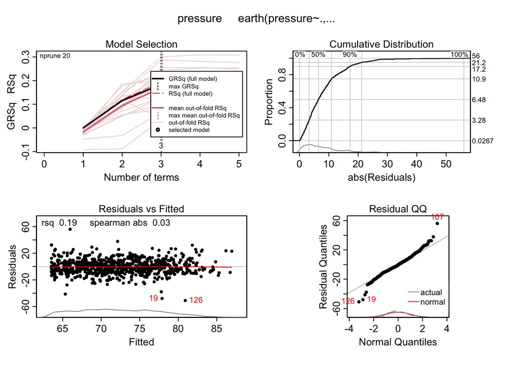

```
##
## training rsq 0.19
```

```r
plot(earth1, info=T, type="response", trace=1)
```

```
## stats::predict(earth.object, NULL, type="response", info=TRUE)
```

```
## stats::fitted(object=earth.object)
## got model response from object$y
##
##  plotmo grid:    pregnant glucose triceps insulin mass pedigree age
##                         3     117      29     125 32.3   0.3725  29
##  diabetes miss_glucose miss_pressure miss_triceps miss_insulin miss_mass
##         0            0             0            0            0         0
```

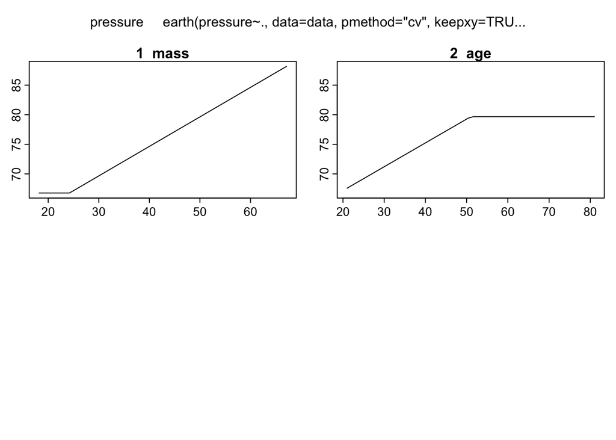

```r
plotmo(earth1, info=T, type="response", trace=1)#, level=.9)
```

```r
# 3d MARS plots!
# same syntactical rules apply here as well
plotmo(earth1)
```

[output not shown]

```
##  plotmo grid:    pregnant glucose triceps insulin mass pedigree age
##                         3     117      29     125 32.3   0.3725  29
##  diabetes miss_glucose miss_pressure miss_triceps miss_insulin miss_mass
##         0            0             0            0            0         0
```

```
##  plotmo grid:    pregnant glucose triceps insulin mass pedigree age
##                         3     117      29     125 32.3   0.3725  29
##  diabetes miss_glucose miss_pressure miss_triceps miss_insulin miss_mass
##         0            0             0            0            0         0
```

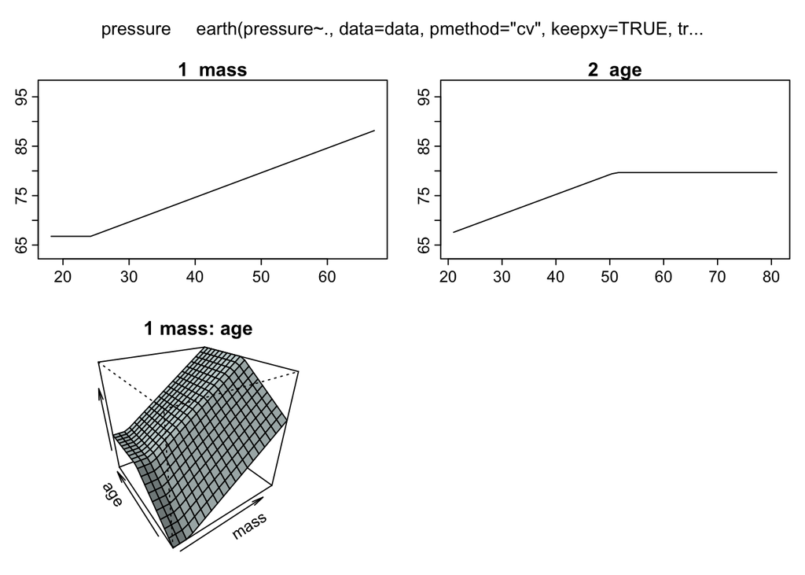

```r
plotmo(earth1, all2=TRUE, persp.col="azure")
```

We can also see the ideal number of terms

```r
control <- trainControl(method = "repeatedcv",
                        repeats = 1, number = 1)

grid <- expand.grid(.degree = 1, .nprune = 2:25)

earth_best_terms <- train(pressure ~ ., data = data, method = "earth",
tuneGrid= grid)

earth_best_terms
```

```
## Multivariate Adaptive Regression Spline
##
## 768 samples
##  13 predictor
##
## No pre-processing
## Resampling: Bootstrapped (25 reps)
## Summary of sample sizes: 768, 768, 768, 768, 768, 768, ...
## Resampling results across tuning parameters:
##
##   nprune  RMSE      Rsquared
##    2      11.35408  0.1073283
##    3      10.89617  0.1793008
##    4      10.93983  0.1760370
##    5      11.02425  0.1692765
##    6      11.04741  0.1662241
##    7      11.12699  0.1582005
##    8      11.14840  0.1586616
##    9      11.18532  0.1575292
##   10      11.23732  0.1538041
##   11      11.26693  0.1516627
##   12      11.29749  0.1494507
##   13      11.30668  0.1499358
##   14      11.38831  0.1487384
##   15      11.42374  0.1469635
##   16      11.44278  0.1454418
##   17      11.44987  0.1448343
##   18      11.44689  0.1451135
##   19      11.44689  0.1451135
##   20      11.44689  0.1451135
##   21      11.44689  0.1451135
##   22      11.44689  0.1451135
##   23      11.44689  0.1451135
##   24      11.44689  0.1451135
##   25      11.44689  0.1451135
##
## Tuning parameter 'degree' was held constant at a value of 1
## RMSE was used to select the optimal model using  the smallest value.
## The final values used for the model were nprune = 3 and degree = 1.
```

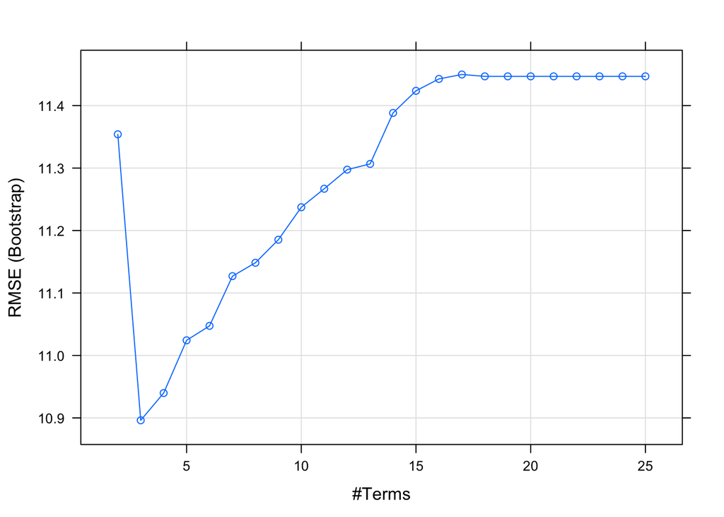

```r
plot(earth_best_terms)
```

TODO: - determine best value for nfold - explore the ncross argument - plot cross validation results - collect $R^2$ in different ways - use cross-validation to select the number of terms - better discuss partial dependence plots - include confidence intervals versus prediction intervals - investigate assumptions of prediction intervals - include text about interpretaiton of 3D plotmo regression surfaces - comprehensively discuss limitations

[See Stephen Milborrow’s excellent notes on earth here](http://www.milbo.org/doc/earth-notes.pdf) for lots of handy tips and tricks.

[… and view his notes on variance models in earth here](http://www.milbo.org/doc/earth-varmod.pdf)

[“earth” R package](https://cran.r-project.org/web/packages/earth/earth.pdf)

[Friedman 1991 - MARS](https://projecteuclid.org/download/pdf_1/euclid.aos/1176347963)

[Friedman 1993- Fast MARS](https://statistics.stanford.edu/sites/default/files/LCS%20110.pdf)